# Business Understanding

Being able to accurately predict the severity of cell tower faults would assist in directing limited repair/maintenance resources to geographically distant locations and proactively mitigate tower outages that can result in network downtime, lost revenues, and breaches in regulations that govern the telecom industry.

# Data Understanding

## Collect Data

```python
import pandas as pd
import numpy as np
from functools import reduce
import matplotlib.pyplot as plt
%matplotlib inline

event_type = pd.read_csv('event_type.csv')
log_feature = pd.read_csv('log_feature.csv')
resource_type = pd.read_csv('resource_type.csv')
severity_type = pd.read_csv('severity_type.csv')

csv_list = [event_type,log_feature,resource_type,severity_type]
```

Each feature in this dataset is stored in a separate CSV file and can be integrated by merging on the column 'id'

```python
df = reduce(lambda left,right: pd.merge(left,right,on='id'), csv_list)
```

The values in some columns are prepended by the name of the column and can be safely removed.

```python
df.head()
```

|  | id | event_type | log_feature | volume | resource_type | severity_type |
| --- | --- | --- | --- | --- | --- | --- |
| 0 | 6597 | event_type 11 | feature 68 | 6 | resource_type 8 | severity_type 2 |
| 1 | 8011 | event_type 15 | feature 68 | 7 | resource_type 8 | severity_type 2 |
| 2 | 2597 | event_type 15 | feature 68 | 1 | resource_type 8 | severity_type 2 |
| 3 | 5022 | event_type 15 | feature 172 | 2 | resource_type 8 | severity_type 1 |
| 4 | 5022 | event_type 15 | feature 56 | 1 | resource_type 8 | severity_type 1 |

```python
# str.extract uses a regex pattern to extract all numeric charcters
df.event_type = df.event_type.str.extract('(\d+)', expand=False)
df.log_feature = df.log_feature.str.extract('(\d+)', expand=False)
df.resource_type = df.resource_type.str.extract('(\d+)', expand=False)
df.severity_type = df.severity_type.str.extract('(\d+)', expand=False)
```

```python
train = pd.read_csv('train.csv')
train.head()
```

|  | id | location | fault_severity |
| --- | --- | --- | --- |
| 0 | 14121 | location 118 | 1 |
| 1 | 9320 | location 91 | 0 |
| 2 | 14394 | location 152 | 1 |
| 3 | 8218 | location 931 | 1 |
| 4 | 14804 | location 120 | 0 |

'train.csv' contains the index, another feature of the dataset 'location' which refers to a unique tower, and the target fault_severity for the unique location/timepoint id.

```python
X = df.merge(train, on='id')
```

Extract only numbers from location

```python
X.location = X.location.str.extract('(\d+)', expand=False)
```

## Describe Data

```python
X.shape
```

```
(61839, 8)
```

```python
X.head()
```

|  | id | event_type | log_feature | volume | resource_type | severity_type | location | fault_severity |
| --- | --- | --- | --- | --- | --- | --- | --- | --- |
| 0 | 8011 | 15 | 68 | 7 | 8 | 2 | 1 | 0 |
| 1 | 2588 | 15 | 82 | 9 | 8 | 1 | 1 | 0 |
| 2 | 2588 | 15 | 201 | 5 | 8 | 1 | 1 | 0 |
| 3 | 2588 | 15 | 80 | 15 | 8 | 1 | 1 | 0 |
| 4 | 2588 | 15 | 203 | 5 | 8 | 1 | 1 | 0 |

Despite being filled with integers, the features in the dataset are all 'types' or 'features'. This is categorical data, with the exception of 'volume' which is discrete interval variable

The 'id' field identifies a unique location-time point. There are no timestamps to tell how far apart the fault observations are from each other and apparently no way to use one of the most useful metrics for making predications about product failures; Mean Time Between Failure. Finding failure prone towers by location seems like it would be a good first place to look when exploring the data.

```python
train.fault_severity.value_counts()
```

```
0    4784
1    1871
2     726
Name: fault_severity, dtype: int64
```

There are a 7,381 fault severity labels that can be used to train a model.

fault_severity (the target variable) should not be confused with severity_type (a categorical feature)

```python
X.severity_type.value_counts()
```

```
1    36571
2    24260
4      920
5       55
3       33
Name: severity_type, dtype: int64
```

```python
X.columns
```

```
Index(['id', 'event_type', 'log_feature', 'volume', 'resource_type',
       'severity_type', 'location', 'fault_severity'],
      dtype='object')
```

### Exploring fault_severity frequency counts

###### Create a Dataframe with all location_id

929 unique location_ids

```python
locations = pd.DataFrame(X.location.unique())
locations.columns=['location']
```

```python
X[X.fault_severity==0].location.value_counts()
```

```
794     1139
126     1020
124      784
122      720
242      654
471      626
102      571
802      544
495      526
476      516
496      447
1095     444
478      435
821      407
497      385
```

[output cut: 47 more lines]

```python
fault_sev_0 = pd.DataFrame(X[X.fault_severity==0].location.value_counts())
fault_sev_0.columns = ['fault_0']
```

```python
fault_sev_0['location']=fault_sev_0.index
```

```python
fault_sev_0.head()
```

|  | fault_0 | location |
| --- | --- | --- |
| 794 | 1139 | 794 |
| 126 | 1020 | 126 |
| 124 | 784 | 124 |
| 122 | 720 | 122 |
| 242 | 654 | 242 |

###### Count fault_severity of 1 for all locations

```python
fault_sev_1 = pd.DataFrame(X[X.fault_severity==1].location.value_counts())
fault_sev_1.columns = ['fault_1']
fault_sev_1['location']=fault_sev_1.index
```

```python
fault_sev_1.head()
```

|  | fault_1 | location |
| --- | --- | --- |
| 821 | 430 | 821 |
| 856 | 378 | 856 |
| 661 | 364 | 661 |
| 73 | 341 | 73 |
| 627 | 297 | 627 |

###### Count fault-severity of 2 for all locations

```python
fault_sev_2 = pd.DataFrame(X[X.fault_severity==2].location.value_counts())
fault_sev_2.columns = ['fault_2']
fault_sev_2['location']=fault_sev_2.index
```

```python
fault_sev_2.head()
```

|  | fault_2 | location |
| --- | --- | --- |
| 13 | 506 | 13 |
| 734 | 450 | 734 |
| 745 | 403 | 745 |
| 821 | 353 | 821 |
| 1107 | 314 | 1107 |

```python
fault_list = [locations,fault_sev_0,fault_sev_1,fault_sev_2]

# pd.merge defaults to inner merges (how='inner').  This means that only locations with fault_0, fault_1, fault_2 will be included in the resulting dataframe

# Specify how='outer' merge here ensures that if a location is missing any of the fault severities it will still be included
#  in the resulting dataframe but display a 'NaN' which can you see in the dataframe head below
faults_by_location = reduce(lambda left,right: pd.merge(left,right,on='location', how='outer'), fault_list)
faults_by_location.head()
```

|  | location | fault_0 | fault_1 | fault_2 |
| --- | --- | --- | --- | --- |
| 0 | 1 | 83.0 | 66.0 | 14.0 |
| 1 | 10 | 2.0 | NaN | NaN |
| 2 | 100 | 91.0 | 5.0 | NaN |
| 3 | 1000 | 29.0 | NaN | NaN |
| 4 | 1002 | 2.0 | NaN | NaN |

```python
faults_by_location.shape
```

```
(929, 4)
```

```python
faults_by_location.fillna(0, inplace=True)
```

###### Create fault_total field

```python
faults_by_location['fault_total']= faults_by_location.fault_0 + faults_by_location.fault_1 + faults_by_location.fault_2
```

```python
faults_by_location.head()
```

|  | location | fault_0 | fault_1 | fault_2 | fault_total |
| --- | --- | --- | --- | --- | --- |
| 0 | 1 | 83.0 | 66.0 | 14.0 | 163.0 |
| 1 | 10 | 2.0 | 0.0 | 0.0 | 2.0 |
| 2 | 100 | 91.0 | 5.0 | 0.0 | 96.0 |
| 3 | 1000 | 29.0 | 0.0 | 0.0 | 29.0 |
| 4 | 1002 | 2.0 | 0.0 | 0.0 | 2.0 |

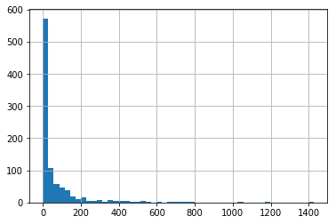

```python
faults_by_location.fault_total.hist(bins=50)
```

The heavy positive skew on this distribution shows that vast majority of tower locations make few recordings.

```python
faults_by_location.fault_total.max()
```

```
1425.0
```

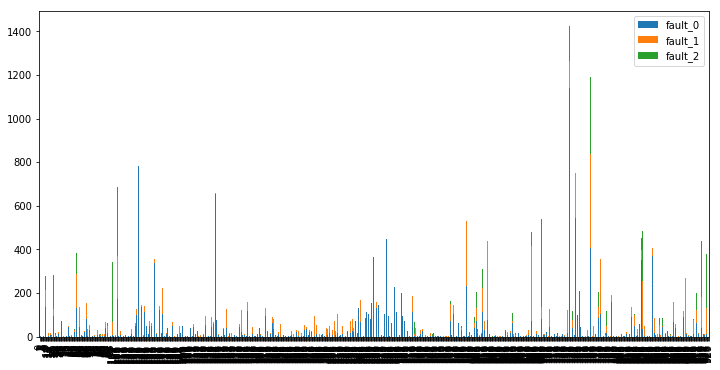

```python
faults_by_location[['fault_0','fault_1','fault_2']].plot(kind='bar', stacked=True, figsize=(12,6))
```

###### Sort plot by total faults in descending order

```python
sorted_faults_by_location = faults_by_location.sort_values('fault_total', axis=0, ascending=False)
```

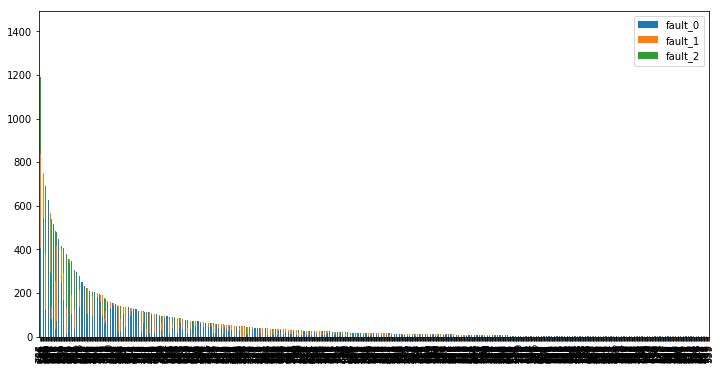

```python
sorted_faults_by_location[['fault_0','fault_1','fault_2']].plot(kind='bar', stacked=True, figsize=(12,6))
```

The plot above mimics the histogram of total_faults by location above, but attempts to visualize the category of each fault reading. Perhaps creating a smaller of subset would help.

```python
sorted_faults_by_location.fault_total.describe()
```

```
count     929.000000
mean       66.565124
std       135.806841
min         1.000000
25%         4.000000
50%        17.000000
75%        64.000000
max      1425.000000
Name: fault_total, dtype: float64
```

Its possible to zoom in on a specific subset and see if certain 'fault_types' are more prevelant at towers that log a similar number of features

```python
total_fault_upper_limit = 4
total_fault_lower_limit = 1
```

```python
index_subset = ((sorted_faults_by_location.fault_total<= total_fault_upper_limit) & (sorted_faults_by_location.fault_total>=total_fault_lower_limit))
```

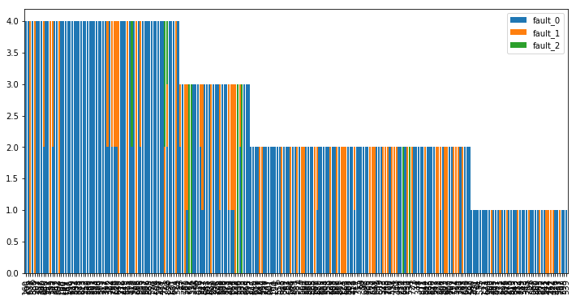

```python
sorted_faults_by_location.loc[index_subset,['fault_0','fault_1','fault_2']].plot(kind='bar', stacked=True, figsize=(12,6), width=0.8)
```

Possible future areas of exploration are:

1. Identifying location_id's with a high number of fault_1 and fault_2 counts
2. Identifying location_id's with a high percentage of fault_1 or 2 of the total number of faults

### Prepping Volume, the only discrete interval variable

Only 'volume' is a non-categorical variable

Volume shows heavy positive skew

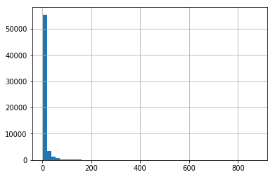

```python
X.volume.hist(bins=50)
```

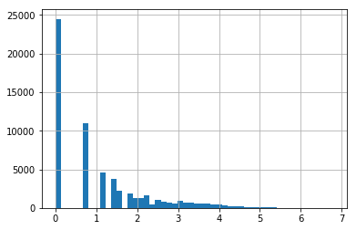

```python
np.log(X.volume).hist(bins=50)
```

```python
volume_log = np.log(X.volume)
```

```python
X['volume_log']=np.ceil(volume_log)
```

```python
X.drop('volume', axis=1, inplace=True)
```

There is a large positive skew in log_volume. Decision Trees are not hindered by skewed data and would be a decent place to start